# Assignment 4

Avery Davidowitz

2022-10-05

## Introduction

This assignment loads, munges and analyses airline flight data. The data is initially messy and tools from the Tidyverse are used to standardize it into a “tidy” format. A plot is then used to highlight trends in the data.

## Import Libraries

```r
library(tidyverse)
```

## Load Data

Load the data from a CSV file stored on Github for reproducibility.

```r
theUrl <- "https://raw.githubusercontent.com/adavidowitz100/DATA607/main/Assignment4/Flight_Data.csv"
flight_data <- read.table(file=theUrl, header=TRUE, sep=",")
as_tibble(flight_data)
```

```
## # A tibble: 5 × 7
##   X         X.1       Los.Angeles Phoenix San.Diego San.Francisco Seattle
##   <chr>     <chr>           <int>   <int>     <int>         <int>   <int>
## 1 "ALASKA"  "on time"         497     221       212           503    1841
## 2 ""        "delayed"          62      12        20           102     305
## 3 ""        ""                 NA      NA        NA            NA      NA
## 4 "AM WEST" "on time"         694    4840       383           320     201
## 5 ""        "delayed"         117     415        65           129      61
```

## Data Munging into Tidy Data

Remove blank rows

```r
flight_data <- flight_data[rowSums(is.na(flight_data) | flight_data == "") != ncol(flight_data),]
head(flight_data)
```

```
##         X     X.1 Los.Angeles Phoenix San.Diego San.Francisco Seattle
## 1  ALASKA on time         497     221       212           503    1841
## 2         delayed          62      12        20           102     305
## 4 AM WEST on time         694    4840       383           320     201
## 5         delayed         117     415        65           129      61
```

Rename Columns

```r
flight_data <- flight_data |> dplyr::rename("Airline" = X, "Status" = X.1)
head(flight_data)
```

```
##   Airline  Status Los.Angeles Phoenix San.Diego San.Francisco Seattle
## 1  ALASKA on time         497     221       212           503    1841
## 2         delayed          62      12        20           102     305
## 4 AM WEST on time         694    4840       383           320     201
## 5         delayed         117     415        65           129      61
```

Fill missing Airline values

```r
flight_data[flight_data==""]<-NA
flight_data <- tidyr::fill(flight_data, Airline, .direction = "down")
head(flight_data)
```

```
##   Airline  Status Los.Angeles Phoenix San.Diego San.Francisco Seattle
## 1  ALASKA on time         497     221       212           503    1841
## 2  ALASKA delayed          62      12        20           102     305
## 4 AM WEST on time         694    4840       383           320     201
## 5 AM WEST delayed         117     415        65           129      61
```

Convert data from wide format to Tidy long format by moving city counts from multiple columns to 2 new city and count name/value columns

```r
long_flight_data <- tidyr::pivot_longer(flight_data, c(Los.Angeles, Phoenix, San.Diego, San.Francisco, Seattle), names_to = "City", values_to = "Count")
head(long_flight_data)
```

```
## # A tibble: 6 × 4
##   Airline Status  City          Count
##   <chr>   <chr>   <chr>         <int>
## 1 ALASKA  on time Los.Angeles     497
## 2 ALASKA  on time Phoenix         221
## 3 ALASKA  on time San.Diego       212
## 4 ALASKA  on time San.Francisco   503
## 5 ALASKA  on time Seattle        1841
## 6 ALASKA  delayed Los.Angeles      62
```

Remove periods from City names

```r
long_flight_data$City <- sub("\\.", " ", long_flight_data$City)
head(long_flight_data)
```

```
## # A tibble: 6 × 4
##   Airline Status  City          Count
##   <chr>   <chr>   <chr>         <int>
## 1 ALASKA  on time Los Angeles     497
## 2 ALASKA  on time Phoenix         221
## 3 ALASKA  on time San Diego       212
## 4 ALASKA  on time San Francisco   503
## 5 ALASKA  on time Seattle        1841
## 6 ALASKA  delayed Los Angeles      62
```

## Analysis

Adding in a column for the percentage of flights with delays for each airline/city observation. This enables a better comparison of performance across the two airlines. A bar plot of the relative delays shows a clear trend.

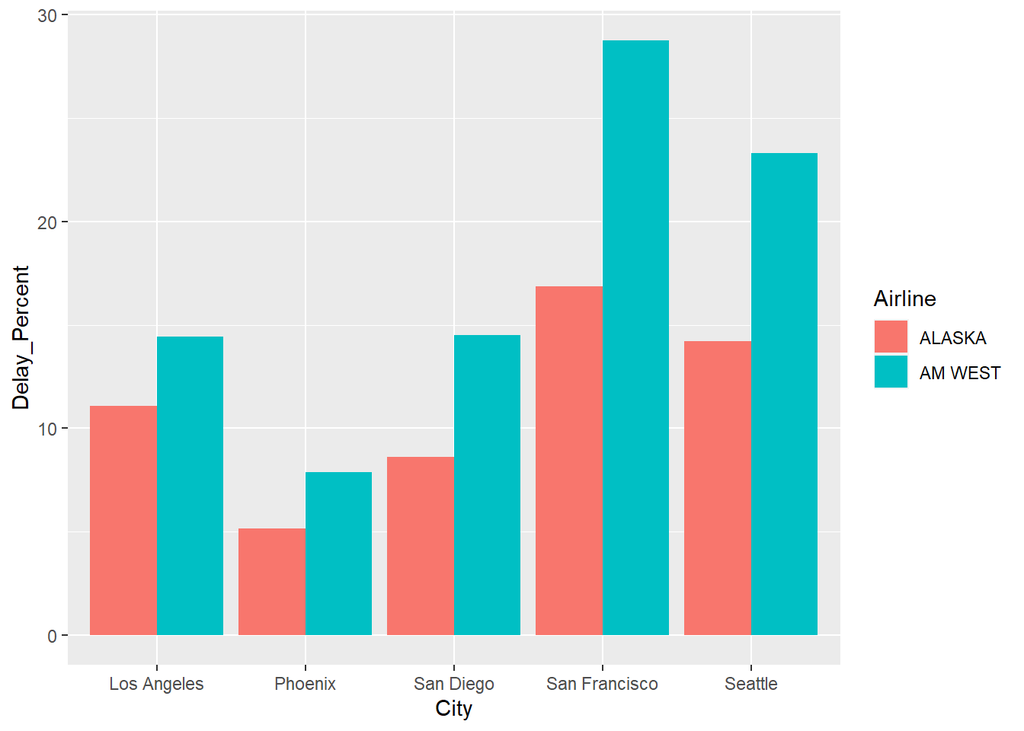

```r
long_flight_data_delay <- long_flight_data |> dplyr::group_by(Airline, City) |>
  dplyr::mutate(Delay_Percent = Count / sum(Count) * 100) |>
  dplyr::filter(Status=="delayed") |>
  dplyr::select(Airline, City, Delay_Percent)

ggplot(long_flight_data_delay, aes(x=City, y=Delay_Percent, fill=Airline)) +
    geom_bar(stat='identity', position='dodge')
```

## Conclusion

From examining the plotted ratios of flight delays, AM West has a significantly worse delay performance for the five cities in question. AM West on-time performance lagged behind Alaska Airlines in every city but had a significant gap in San Francisco and Seattle specifically. The analysis is hampered somewhat in scope because the data is an aggregated categorical data point of delayed/on-time. A numerical measure of delay times could yield more interesting results.